# Impact Of Borrower Features On Loan Performance (Estimated Return)

## Investigation Overview

In this investigation, I wanted to look at borrower features that will have the largest effect on the performance of the loan (Estimated return). The main focus was on a few main variables, Loan Status, IncomeRange, DebtToIncomeRatio, Prosper Rating (Alpha), average credit score* and employment status; as it may potentially have the largest effect on the performance of the loan so makes the most sense.

## Dataset Overview

This notebook explores a dataset containing peer-to-peer loan information of 113,937 loans with 80 variables on each loan from Prosper Funding LLC. The variables are a mix of quantitative variables and categorical variables. Along with the dataset, a feature dictionary describing the variables was also provided [here](https://docs.google.com/spreadsheets/d/1gDyi_L4UvIrLTEC6Wri5nbaMmkGmLQBk-Yx3z0XDEtI/edit#gid=0).

You will find that the file (prosperLoanData.csv) isn't uploaded in the repository since we have added it to the google drive then extracted here in this colab notebook for analysis.

## Distribution of Estimated Return

It appears we have quite a few empty cells since the total number of rows is over 100,000. That had been removed before plotting the distribution of returns.After cleaning the data, here were the key observations:

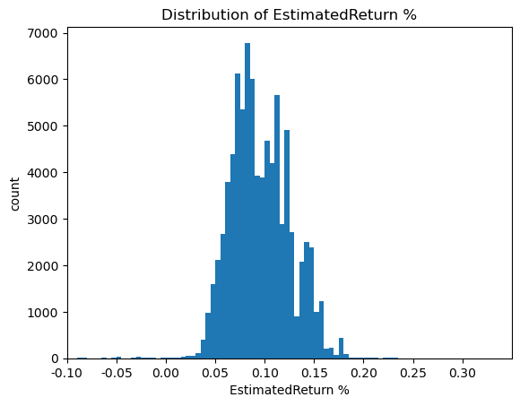

## Distribution of Prosper Rating (Alpha)

It appears we have quite a few empty cells since the total number of rows is over 100,000. That had been removed before plotting the distribution of returns.

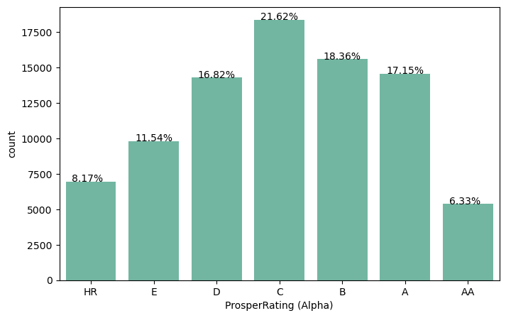

## Estimated Return vs. Prosper Rating (Alpha)

Plotting Estimated Returns vs Propser Rating (Alpha), it was observed that generally, there was a strong negative relationship. The higher the rating, the lower the estimated returns are.

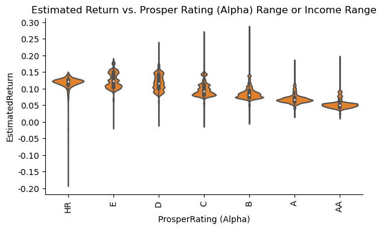

## Estimated Returns vs. Term Duration & Prosper Ratings (Alpha)

For each individual term over every rating, the return decreases as the rating increases. However, diving deeper into loan term length, across all ratings, the longer the term of the loan, the higher the estimated return is.

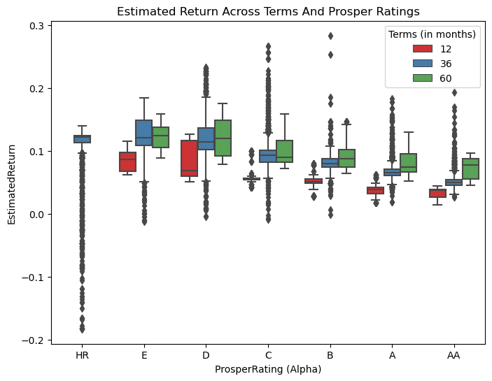

## EstimatedReturn vs. Employment Status & Prosper Ratings

We can see how Employment Status affects estimated returns price by through this chart where for E & D borrowers, retired workers are seeing higher estimated return vs. unemployed workers. For C to AA, unemployed workers tend to have the higest rate of return.

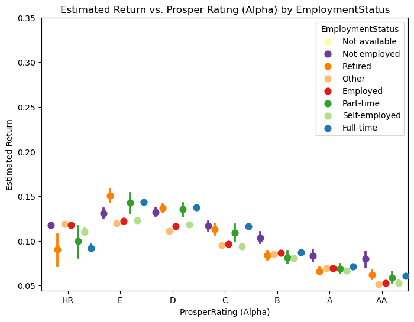

## EstimatedReturn vs. Income Range & Credit Score

Diving into other cuts of categorical data like Income Range & Credit Score, across income ranges $25,000 to $100,000+, most of the dark color areas are in a downward trending pattern, meaning that a higher credit score leads to lower estimated returns. For lower income ranges however, the pattern is not as obvious and the heatmap is more scattered.

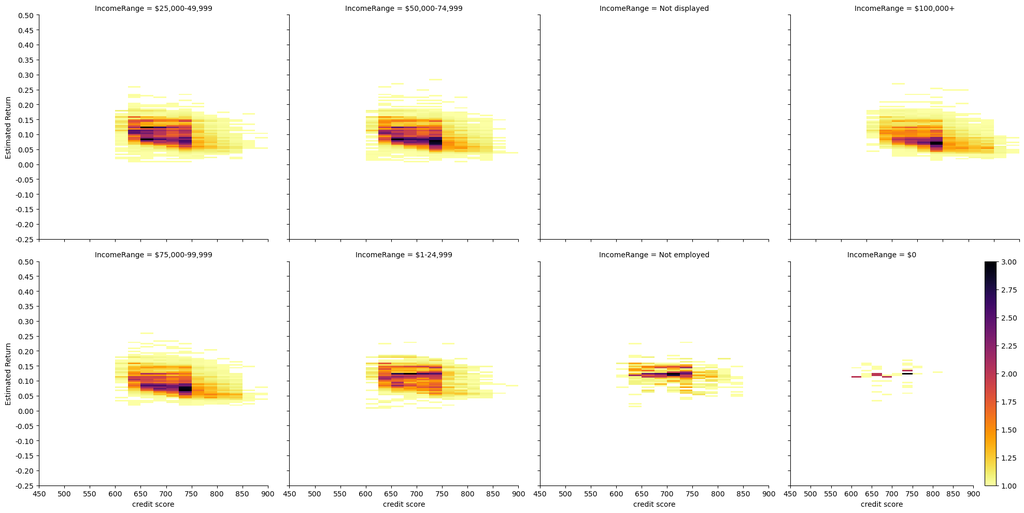